# Logistic Regression Assignment

Mohd Azmi, Mohd Khairul Anwar, Muhamad Zikri, Muhd Firdaus

07/12/2019

# 1 Introduction

## 1.1 Research Problem

The dataset is taken from National Burn Repository 2007 Report (Hosmer, 2013). In this study, they record the hospital discharge status, patient’s gender, patient’s ethnicity, total burn surface area, inhalation injury and flame involvement. 1,000 data were collected (from total of 40,000 original data) in the dataset, BURN1000, which oversampled patient who died in hospital and undersampled subject who lived.

In this study, we would like to ascertain factors associated with death upon discharge among the burn injury patient.

## 1.2 Packages

```r
library(pacman)
p_load(dplyr, psych, knitr, ggplot2, broom, LogisticDx, generalhoslem, ResourceSelection)
```

## 1.3 Data

```r
burnDS <- read.delim("BURN1000.txt", header = TRUE, sep = "\t", dec = ".")

burnDS2 <- burnDS %>%
  mutate(DcStat = factor(DEATH, labels = c("Alive", "Death")),
         Gender = factor(GENDER, labels = c("Female", "Male")),
         Ethnic = factor(RACEC, labels = c("Non-white", "White")),
         Inhale = factor(INH_INJ, labels = c("No", "Yes")),
         Flame = factor(FLAME, labels = c("No", "Yes"))) %>%
  dplyr::select(DcStat, AGE, Gender, Ethnic, TBSA, Inhale, Flame)
```

# 2 Descriptive Analysis

## 2.1 Data Summary

```r
summary(burnDS2)
```

```
##    DcStat         AGE           Gender          Ethnic         TBSA
##  Alive:850   Min.   : 0.10   Female:295   Non-white:411   Min.   : 0.10
##  Death:150   1st Qu.:10.85   Male  :705   White    :589   1st Qu.: 2.50
##              Median :31.95                                Median : 6.00
##              Mean   :33.29                                Mean   :13.54
##              3rd Qu.:51.23                                3rd Qu.:16.00
##              Max.   :89.70                                Max.   :98.00
##  Inhale    Flame
##  No :878   No :471
##  Yes:122   Yes:529
##
##
##
##
```

The distribution of each variable, grouped by discharge status, shown as below

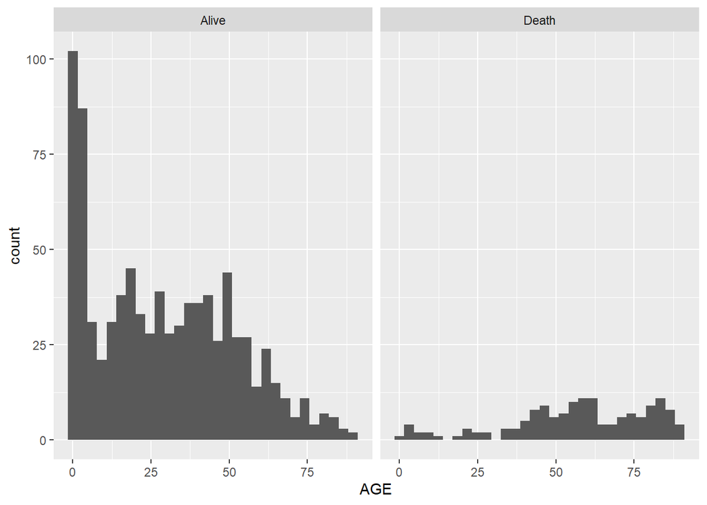

```r
ggplot(burnDS2, aes(x=AGE)) + geom_histogram() + facet_wrap(~DcStat)
```

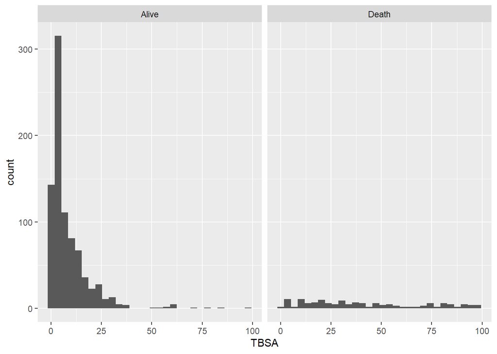

```r
ggplot(burnDS2, aes(x=TBSA)) + geom_histogram() + facet_wrap(~DcStat)
```

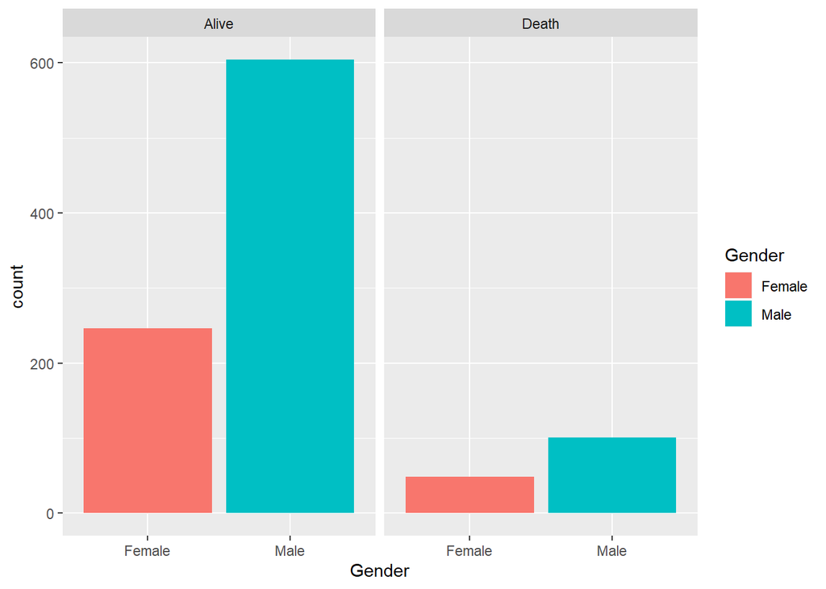

```r
ggplot(burnDS2, aes(x=Gender, fill=Gender)) + geom_bar() + facet_wrap(~DcStat)
```

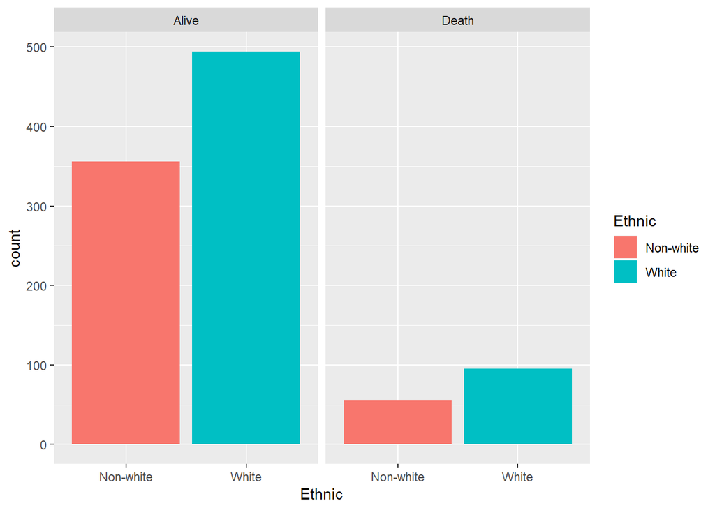

```r
ggplot(burnDS2, aes(x=Ethnic, fill=Ethnic)) + geom_bar() + facet_wrap(~DcStat)
```

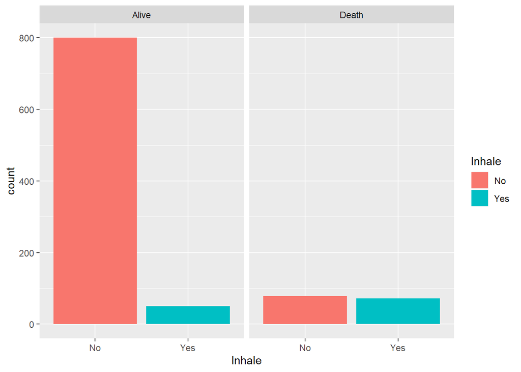

```r
ggplot(burnDS2, aes(x=Inhale, fill=Inhale)) + geom_bar() + facet_wrap(~DcStat)
```

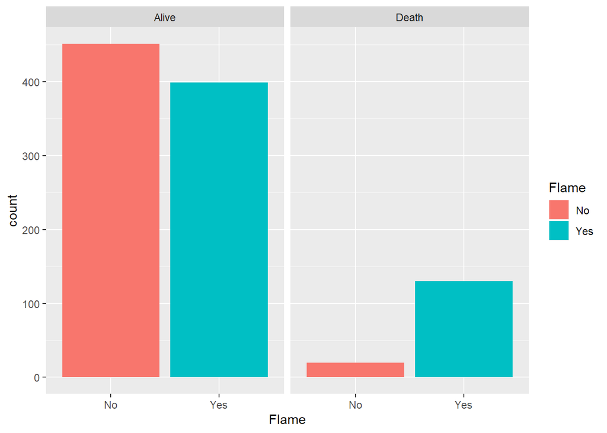

```r
ggplot(burnDS2, aes(x=Flame, fill=Flame)) + geom_bar() + facet_wrap(~DcStat)
```

# 3 Univariable Analysis

Univariable analysis with Simple Logistic Regression show variable age at admission, % total burn surface area, inhalation injury and flame involvement were significant associated with discharge status at p < 0.05, while there was no significant association between ethnicity and discharge status.

For each increment of 1 year of age of admission, the log odds of death upon discharge change by 0.05 (95% CI = 0.04, 0.06, p < 0.01). For each increament of 1% of total burn surface area, the log odds of death upon discharge change by 0.09 (95% CI = 0.07, 0.10, p < 0.001). As compared to those without inhalation injury, the odd ratio of death upon discharge among those with inhalation injury 14.77 (95% CI = 9.66, 22.81, p < 0.001). As compared to those without flame invovlement, the odd ratio of death upon discharge among those = with flame involvement was 7.35 (95% CI = 4.61, 12.33, p < 0.01)

The detail of univariable analysis was as below.

```r
SLogR_all <- burnDS2 %>%
  dplyr::select(AGE, Gender, Ethnic, TBSA, Inhale, Flame) %>%
  purrr::map(~glm(DcStat ~.x, data = burnDS2, family = binomial)) %>%
  purrr::map(tidy) %>%
  bind_rows()

SLogR_all %>%
  mutate(model = c("b0", "Age (year)", "b0", "Gender - Male", "b0", "Ethnic - White", "b0", "TBSA (%)", "b0", "Inhalation Injury - Yes", "b0", "Flame Invovlement - Yes")) %>%
  dplyr::select(model, everything()) %>%
  kable
```

| model | term | estimate | std.error | statistic | p.value |
| --- | --- | --- | --- | --- | --- |
| b0 | (Intercept) | -4.0550539 | 0.2625640 | -15.444060 | 0.0000000 |
| Age (year) | .x | 0.0532536 | 0.0047022 | 11.325146 | 0.0000000 |
| b0 | (Intercept) | -1.6135112 | 0.1564391 | -10.313987 | 0.0000000 |
| Gender - Male | .xMale | -0.1749424 | 0.1898152 | -0.921646 | 0.3567133 |
| b0 | (Intercept) | -1.8675975 | 0.1448819 | -12.890481 | 0.0000000 |
| Ethnic - White | .xWhite | 0.2189389 | 0.1831430 | 1.195453 | 0.2319101 |
| b0 | (Intercept) | -3.3451075 | 0.1756480 | -19.044384 | 0.0000000 |
| TBSA (%) | .x | 0.0853668 | 0.0069560 | 12.272374 | 0.0000000 |
| b0 | (Intercept) | -2.3279029 | 0.1186192 | -19.625012 | 0.0000000 |
| Inhalation Injury - Yes | .xYes | 2.6925460 | 0.2189963 | 12.294936 | 0.0000000 |
| b0 | (Intercept) | -3.1157350 | 0.2284707 | -13.637349 | 0.0000000 |
| Flame Invovlement - Yes | .xYes | 1.9943080 | 0.2497948 | 7.983785 | 0.0000000 |

```r
SLogR_Age <- glm(DcStat ~ AGE, data = burnDS2, family = binomial)
Table_SLogR_Age <- tidy(SLogR_Age)
CI_SLogR_Age <- confint(SLogR_Age)
OR_SLogR_Age <- exp(coef(SLogR_Age))
ORCI_SLogR_Age <- exp(confint(SLogR_Age))
kable(cbind(Table_SLogR_Age, CI_SLogR_Age, OR_SLogR_Age, ORCI_SLogR_Age))
```

|  | term | estimate | std.error | statistic | p.value | 2.5 % | 97.5 % | OR_SLogR_Age | 2.5 % | 97.5 % |
| --- | --- | --- | --- | --- | --- | --- | --- | --- | --- | --- |
| (Intercept) | (Intercept) | -4.0550539 | 0.2625640 | -15.44406 | 0 | -4.5939969 | -3.5630221 | 0.0173345 | 0.0101124 | 0.028353 |
| AGE | AGE | 0.0532536 | 0.0047022 | 11.32515 | 0 | 0.0443184 | 0.0627835 | 1.0546970 | 1.0453152 | 1.064796 |

```r
SLogR_TBSA <- glm(DcStat ~ TBSA, data = burnDS2, family = binomial)
Table_SLogR_TBSA <- tidy(SLogR_TBSA)
CI_SLogR_TBSA <- confint(SLogR_TBSA)
OR_SLogR_TBSA <- exp(coef(SLogR_TBSA))
ORCI_SLogR_TBSA <- exp(confint(SLogR_TBSA))
kable(cbind(Table_SLogR_TBSA, CI_SLogR_TBSA, OR_SLogR_TBSA, ORCI_SLogR_TBSA))
```

|  | term | estimate | std.error | statistic | p.value | 2.5 % | 97.5 % | OR_SLogR_TBSA | 2.5 % | 97.5 % |
| --- | --- | --- | --- | --- | --- | --- | --- | --- | --- | --- |
| (Intercept) | (Intercept) | -3.3451075 | 0.175648 | -19.04438 | 0 | -3.7045422 | -3.0147021 | 0.0352564 | 0.0246115 | 0.0490605 |
| TBSA | TBSA | 0.0853668 | 0.006956 | 12.27237 | 0 | 0.0723993 | 0.0996946 | 1.0891164 | 1.0750845 | 1.1048334 |

```r
SLogR_Inhale <- glm(DcStat ~ Inhale, data = burnDS2, family = binomial)
Table_SLogR_Inhale <- tidy(SLogR_Inhale)
OR_SLogR_Inhale <- exp(coef(SLogR_Inhale))
ORCI_SLogR_Inhale <- exp(confint(SLogR_Inhale))
kable(cbind(Table_SLogR_Inhale, OR_SLogR_Inhale, ORCI_SLogR_Inhale))
```

|  | term | estimate | std.error | statistic | p.value | OR_SLogR_Inhale | 2.5 % | 97.5 % |
| --- | --- | --- | --- | --- | --- | --- | --- | --- |
| (Intercept) | (Intercept) | -2.327903 | 0.1186192 | -19.62501 | 0 | 0.09750 | 0.0766782 | 0.1221486 |
| InhaleYes | InhaleYes | 2.692546 | 0.2189963 | 12.29494 | 0 | 14.76923 | 9.6563246 | 22.8139335 |

```r
SLogR_Flame <- glm(DcStat ~ Flame, data = burnDS2, family = binomial)
Table_SLogR_Flame <- tidy(SLogR_Flame)
OR_SLogR_Flame <- exp(coef(SLogR_Flame))
ORCI_SLogR_Flame <- exp(confint(SLogR_Flame))
kable(cbind(Table_SLogR_Flame, OR_SLogR_Flame, ORCI_SLogR_Flame))
```

|  | term | estimate | std.error | statistic | p.value | OR_SLogR_Flame | 2.5 % | 97.5 % |
| --- | --- | --- | --- | --- | --- | --- | --- | --- |
| (Intercept) | (Intercept) | -3.115735 | 0.2284707 | -13.637349 | 0 | 0.0443459 | 0.0274119 | 0.0674594 |
| FlameYes | FlameYes | 1.994308 | 0.2497948 | 7.983785 | 0 | 7.3471173 | 4.6060252 | 12.3256720 |

# 4 Multivariable Analysis

## 4.1 Preliminary Main Effect Models

Several Preliminary Main Effect Models were formed.

For Preliminary Main Effect Model 1, all variables were selected. Multivariable analysis with multiple logistic regression show that all variable except variables for gender and flame involvement were significant.

```r
PMEM1 <- glm(DcStat ~ AGE + Gender + Ethnic + TBSA + Inhale + Flame, data=burnDS2, family = binomial)
kable(tidy(PMEM1))
```

| term | estimate | std.error | statistic | p.value |
| --- | --- | --- | --- | --- |
| (Intercept) | -7.6951527 | 0.6911691 | -11.1335318 | 0.0000000 |
| AGE | 0.0828903 | 0.0086292 | 9.6057427 | 0.0000000 |
| GenderMale | -0.2014936 | 0.3077836 | -0.6546599 | 0.5126867 |
| EthnicWhite | -0.7013889 | 0.3097808 | -2.2641459 | 0.0235651 |
| TBSA | 0.0893447 | 0.0090868 | 9.8323327 | 0.0000000 |
| InhaleYes | 1.3652775 | 0.3617800 | 3.7737778 | 0.0001608 |
| FlameYes | 0.5825782 | 0.3544931 | 1.6434118 | 0.1002978 |

All significant variables (at p < 0.05) in univariable analysis were selected for preliminary main effect model2 (i.e variable gender and ethnic were removed). Multivariable analysis with multiple logistic regression show that variable age, total burn surface area and inhalation injury involvement were significant.

```r
PMEM2 <- glm(DcStat ~ AGE + TBSA + Inhale + Flame, data=burnDS2, family = binomial)
kable(tidy(PMEM2))
```

| term | estimate | std.error | statistic | p.value |
| --- | --- | --- | --- | --- |
| (Intercept) | -7.9589740 | 0.6342175 | -12.549282 | 0.0000000 |
| AGE | 0.0798872 | 0.0081425 | 9.811117 | 0.0000000 |
| TBSA | 0.0873995 | 0.0089890 | 9.722964 | 0.0000000 |
| InhaleYes | 1.3828022 | 0.3541921 | 3.904102 | 0.0000946 |
| FlameYes | 0.4437575 | 0.3466829 | 1.280010 | 0.2005418 |

For Preliminary Main Effect Model 3, variable flame involvement was removed. Multivariable analysis with multiple logistic regression show that age, total burn surface area and inhalation injury were significant with death upon discharge status.

```r
PMEM3 <- glm(DcStat ~ AGE + TBSA + Inhale, data=burnDS2, family = binomial)
kable(tidy(PMEM3))
```

| term | estimate | std.error | statistic | p.value |
| --- | --- | --- | --- | --- |
| (Intercept) | -7.7427900 | 0.6011512 | -12.879937 | 0.00e+00 |
| AGE | 0.0808919 | 0.0080989 | 9.987994 | 0.00e+00 |
| TBSA | 0.0888506 | 0.0090046 | 9.867227 | 0.00e+00 |
| InhaleYes | 1.4997104 | 0.3446146 | 4.351848 | 1.35e-05 |

### 4.1.1 Model Selection

All preliminary main effect models were compared. There was significant different between Preliminary Main Effect Model 1 and 2, thus Preliminary Main Effect Model 1 were selected because the variables removed in model 2 have effect on the model. There was no significant difference between Model 1 and Model 3, thus model 3 was selected, because it is more parsimonous.

```r
anova(PMEM1, PMEM2, test = "Chisq")
```

```
## Analysis of Deviance Table
##
## Model 1: DcStat ~ AGE + Gender + Ethnic + TBSA + Inhale + Flame
## Model 2: DcStat ~ AGE + TBSA + Inhale + Flame
##   Resid. Df Resid. Dev Df Deviance Pr(>Chi)
## 1       993     336.46
## 2       995     342.50 -2  -6.0339  0.04895 *
## ---
## Signif. codes:  0 '***' 0.001 '**' 0.01 '*' 0.05 '.' 0.1 ' ' 1
```

```r
anova(PMEM1, PMEM3, test = "Chisq")
```

```
## Analysis of Deviance Table
##
## Model 1: DcStat ~ AGE + Gender + Ethnic + TBSA + Inhale + Flame
## Model 2: DcStat ~ AGE + TBSA + Inhale
##   Resid. Df Resid. Dev Df Deviance Pr(>Chi)
## 1       993     336.46
## 2       996     344.18 -3  -7.7166  0.05225 .
## ---
## Signif. codes:  0 '***' 0.001 '**' 0.01 '*' 0.05 '.' 0.1 ' ' 1
```

## 4.2 Main Effect Model

Variables selected for main effect model were age, total burn surface area and inhalation injury.

```r
MainEffectModel <- PMEM3
```

## 4.3 Interaction

All possible interaction between independent variable were tested.

### 4.3.1 Age and TBSA interaction

There was no significant interaction term between age on admission and total burn surface area.

```r
MEM_AgeTBSAInt <- glm(DcStat ~ AGE + TBSA + Inhale + AGE:TBSA, data=burnDS2, family = binomial)
kable(tidy(MEM_AgeTBSAInt))
```

| term | estimate | std.error | statistic | p.value |
| --- | --- | --- | --- | --- |
| (Intercept) | -7.7159283 | 0.6858274 | -11.2505402 | 0.0000000 |
| AGE | 0.0803470 | 0.0105308 | 7.6297313 | 0.0000000 |
| TBSA | 0.0877581 | 0.0162038 | 5.4158934 | 0.0000001 |
| InhaleYes | 1.5037722 | 0.3483009 | 4.3174515 | 0.0000158 |
| AGE:TBSA | 0.0000266 | 0.0003293 | 0.0807705 | 0.9356245 |

### 4.3.2 Age and Inhale

There was significant interaction term between age on admission and inhalation injury.

```r
MEM_AgeInhInt <- glm(DcStat ~ AGE + TBSA + Inhale + AGE:Inhale, data=burnDS2, family = binomial)
kable(tidy(MEM_AgeInhInt))
```

| term | estimate | std.error | statistic | p.value |
| --- | --- | --- | --- | --- |
| (Intercept) | -9.0483261 | 0.7904995 | -11.446340 | 0.00e+00 |
| AGE | 0.1028883 | 0.0111183 | 9.253976 | 0.00e+00 |
| TBSA | 0.0847212 | 0.0090331 | 9.379020 | 0.00e+00 |
| InhaleYes | 4.4938444 | 0.8798881 | 5.107291 | 3.00e-07 |
| AGE:InhaleYes | -0.0555249 | 0.0148129 | -3.748414 | 1.78e-04 |

### 4.3.3 TBSA and Inhale

There was no significant interaction between Total Burn Surface Area and inhalation injury.

```r
MEM_TBSAInhInt <- glm(DcStat ~ AGE + TBSA + Inhale + TBSA:Inhale, data=burnDS2, family = binomial)
kable(tidy(MEM_TBSAInhInt))
```

| term | estimate | std.error | statistic | p.value |
| --- | --- | --- | --- | --- |
| (Intercept) | -7.7854072 | 0.6049661 | -12.8691620 | 0.0000000 |
| AGE | 0.0799865 | 0.0081520 | 9.8118962 | 0.0000000 |
| TBSA | 0.0947893 | 0.0116903 | 8.1083689 | 0.0000000 |
| InhaleYes | 1.8112651 | 0.5015113 | 3.6116137 | 0.0003043 |
| TBSA:InhaleYes | -0.0135378 | 0.0158981 | -0.8515363 | 0.3944715 |

## 4.4 Preliminary Final Model

Interaction term between age and inhalation was included in preliminary final model.

```r
PrelimFinalModel <- MEM_AgeInhInt
```

## 4.5 Final Model Assessment

Despite having significant Hosmer Lemeshow Test, the model considered fit with area under ROC curve was 96.7% (95% CI = 95.6%, 97.7%).

```r
kable(tidy(hoslem.test(burnDS2$DcStat, fitted(PrelimFinalModel), g=10)))
```

| statistic | p.value | parameter | method |
| --- | --- | --- | --- |
| 1000 | 0 | 8 | Hosmer and Lemeshow goodness of fit (GOF) test |

the ROC curve was shown below

```r
PFM_GOF <- gof(PrelimFinalModel)
```

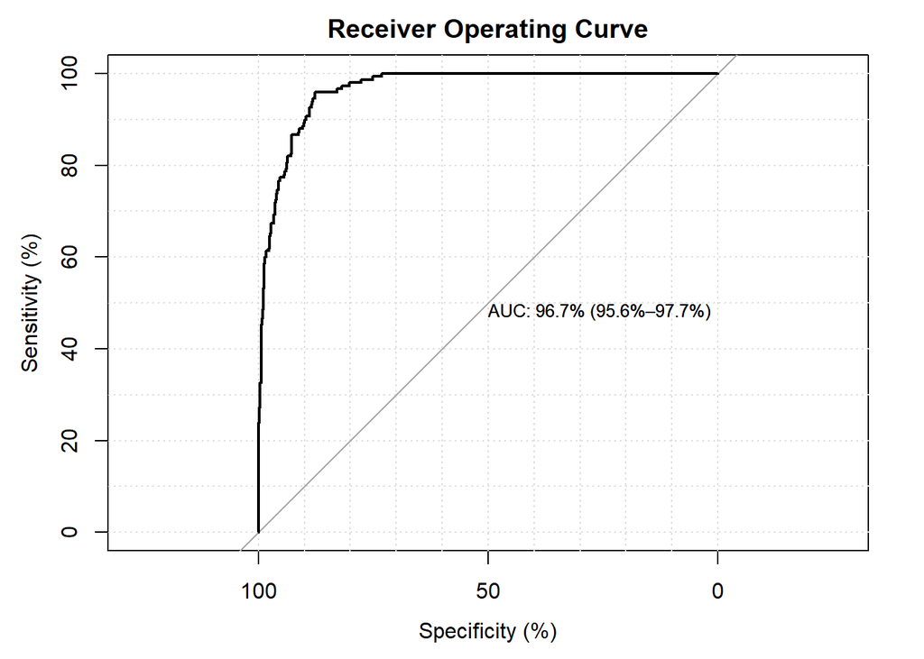

## 4.6 Final Model

Thus, our final model include variable age, tbsa, inhalation injury and one interaction term of age by inhalation.

For each increment of 1 year of age of admission, the log odds of death upon discharge change by 0.10 (95% CI = 0.08, 0.13, p < 0.001), when adjusted to total surface burn area, inhalation injury and interaction term of age by inhalation injury. For each increment of 1% of total surface burn area, the log odds of death upon discharge change by 0.08 (95% CI = 0.07, 0.10, p < 0.001), when adjusted to age on admission, inhalation injury and interaction term of age by inhalation injury. As compared to those without inhalation injury, the odd ratio of death upon discharge among those with inhalation injury was 89.46 (95% CI = 16.26, 520.84), when adjusted to age on admission, total burn surface area and interaction term of age by inhalation injury.

The detail of multiple logistic regresson was shown below.

```r
FinalModel <- glm(DcStat ~ AGE + TBSA + Inhale + AGE:Inhale, data=burnDS2, family = binomial)
Table_FinalModel <- tidy(FinalModel)
CI_FinalModel <- confint(FinalModel)
OR_FinalModel <- exp(coef(FinalModel))
ORCI_FinalModel <- exp(confint(FinalModel))
kable(cbind(Table_FinalModel, CI_FinalModel, OR_FinalModel, ORCI_FinalModel))
```

|  | term | estimate | std.error | statistic | p.value | 2.5 % | 97.5 % | OR_FinalModel | 2.5 % | 97.5 % |
| --- | --- | --- | --- | --- | --- | --- | --- | --- | --- | --- |
| (Intercept) | (Intercept) | -9.0483261 | 0.7904995 | -11.446340 | 0.00e+00 | -10.7199973 | -7.6142177 | 0.0001176 | 0.0000221 | 0.0004934 |
| AGE | AGE | 0.1028883 | 0.0111183 | 9.253976 | 0.00e+00 | 0.0823835 | 0.1260628 | 1.1083676 | 1.0858722 | 1.1343534 |
| TBSA | TBSA | 0.0847212 | 0.0090331 | 9.379020 | 0.00e+00 | 0.0680838 | 0.1035949 | 1.0884136 | 1.0704550 | 1.1091510 |
| InhaleYes | InhaleYes | 4.4938444 | 0.8798881 | 5.107291 | 3.00e-07 | 2.7886217 | 6.2554392 | 89.4647225 | 16.2585958 | 520.8380807 |
| AGE:InhaleYes | AGE:InhaleYes | -0.0555249 | 0.0148129 | -3.748414 | 1.78e-04 | -0.0849263 | -0.0266175 | 0.9459884 | 0.9185800 | 0.9737336 |

# 5 Prediction

We want to predict the probability of death upon discharge for these parameter

- age: 10 & 50 years old
- tbsa: 2.5% & 16.0%
- inhalataion injury status: yes, no

Based on our model, for those age 10 years old and TBSA of 2.5% without inhalation injury, the probability of death upon discharge are < 0.001, while for those with age 50 years old, with TBSA of 16.0% and with inhalation injury, the probability of death upon discharge are 0.303. The detail of prediction of death upon discharge for other combination of the age listed above were shown below.

```r
NewDS <- expand.grid(AGE = c(10, 50),
                     TBSA = c(2.5, 16),
                     Inhale = c("No", "Yes"))

PredProb_NewDS <- predict(FinalModel, newdata = NewDS, type = "response")
kable(cbind(PredProb_NewDS, NewDS))
```

| PredProb_NewDS | AGE | TBSA | Inhale |
| --- | --- | --- | --- |
| 0.0004065 | 10 | 2.5 | No |
| 0.0243135 | 50 | 2.5 | No |
| 0.0012745 | 10 | 16.0 | No |
| 0.0725359 | 50 | 16.0 | No |
| 0.0204513 | 10 | 2.5 | Yes |
| 0.1219051 | 50 | 2.5 | Yes |
| 0.0614964 | 10 | 16.0 | Yes |
| 0.3034813 | 50 | 16.0 | Yes |

# 6 Discussion

in this study, four factors that have significant association with discharge status, including age at admission, total surface burn area, inhalataion injury and flame involvement. However, when adjusted, only age, total surface burn area and inhalation injury were significant.

From this study, it is shown that increase age, increase total surface burn area and presence of inhalation injury increase the odd of death upon discharge.

The final model can be expressed as

y = - 9.05 + 0.10 (Age) + 0.08 (TBSA) + 4.49 (Inhalation Injury - Yes) - 0.06 (Age * Inhalation Injury).

The model was deemed fit. Significant Hosmer Lemeshow most probably due to large sample size.

# 7 Reference

Hosmer, D., Lemeshow, S. & Sturdivant, R. (2013). Applied logistic regression. Hoboken, New Jersey: Wiley.